# Supervised Learning Project

```python
# Part 1. 1 a - Read all the 3 CSV files as DataFrame and store them into 3 separate variables.
import pandas as pd

# Define the paths to the CSV files
path_normal = "/Users/snbaskarraj/Documents/UT/Supervised Learning/Normal.csv"
path_type_h = "/Users/snbaskarraj/Documents/UT/Supervised Learning/Type_H.csv"
path_type_s = "/Users/snbaskarraj/Documents/UT/Supervised Learning/Type_S.csv"

# Read the CSV files into DataFrames
df_normal = pd.read_csv(path_normal)
df_type_h = pd.read_csv(path_type_h)
df_type_s = pd.read_csv(path_type_s)

# The DataFrames df_normal, df_type_h, and df_type_s now contain the respective data.
```

```python
#Part 1.1 b - Print Shape and columns of all the 3 DataFrames
import pandas as pd

# Assuming you've successfully loaded your DataFrames as df_normal, df_type_h, and df_type_s

# Function to print shape and columns of a DataFrame
def print_info(df, name):
    print(f"Shape of {name}: {df.shape}")  # Print the shape of the DataFrame
    print(f"Columns of {name}: {list(df.columns)}\n")  # Print the columns of the DataFrame

# Print shape and columns of each DataFrame
print_info(df_normal, 'Normal')
print_info(df_type_h, 'Type_H')
print_info(df_type_s, 'Type_S')
```

```
Shape of Normal: (100, 7)
Columns of Normal: ['P_incidence', 'P_tilt', 'L_angle', 'S_slope', 'P_radius', 'S_Degree', 'Class']

Shape of Type_H: (60, 7)
Columns of Type_H: ['P_incidence', 'P_tilt', 'L_angle', 'S_slope', 'P_radius', 'S_Degree', 'Class']

Shape of Type_S: (150, 7)
Columns of Type_S: ['P_incidence', 'P_tilt', 'L_angle', 'S_slope', 'P_radius', 'S_Degree', 'Class']
```

Make sure to run this code in an environment where the DataFrames (df_normal, df_type_h, df_type_s) have been correctly loaded with the data from your CSV files. This code will print out the shape (number of rows and columns) and the column names for each of the DataFrames.

```python
#Part 1.1 c - Compare Column names of all the 3 DataFrames and clearly write observations
import pandas as pd

# Placeholder for actual DataFrames, replace with the actual DataFrames loaded from your CSV files
df_normal = pd.DataFrame(columns=['A', 'B', 'C'])
df_type_h = pd.DataFrame(columns=['B', 'C', 'D'])
df_type_s = pd.DataFrame(columns=['C', 'D', 'E'])

# Function to compare columns of three DataFrames and print observations
def compare_columns(df1, df2, df3, names):
    columns1 = set(df1.columns)
    columns2 = set(df2.columns)
    columns3 = set(df3.columns)

    # Identifying common and unique columns
    common_columns = columns1.intersection(columns2).intersection(columns3)
    unique_to_df1 = columns1 - columns2 - columns3
    unique_to_df2 = columns2 - columns1 - columns3
    unique_to_df3 = columns3 - columns1 - columns2

    # Printing observations
    print(f"Common columns in all three DataFrames ({names[0]}, {names[1]}, and {names[2]}): {common_columns}")
    print(f"Columns unique to {names[0]}: {unique_to_df1}")
    print(f"Columns unique to {names[1]}: {unique_to_df2}")
    print(f"Columns unique to {names[2]}: {unique_to_df3}\n")

# Compare and print observations
compare_columns(df_normal, df_type_h, df_type_s, ['Normal', 'Type_H', 'Type_S'])
```

```
Common columns in all three DataFrames (Normal, Type_H, and Type_S): {'C'}
Columns unique to Normal: {'A'}
Columns unique to Type_H: set()
Columns unique to Type_S: {'E'}
```

To compare the column names of the three DataFrames and provide observations, you can use the following Python code. This code will identify unique and common columns across the DataFrames and print out observations regarding their similarities and differences.

This script will output:

The common columns that exist in all three DataFrames. The columns that are unique to each DataFrame. This script will help you understand the similarities and differences in the structure of your DataFrames, which is crucial for tasks like merging, joining, and analyzing data across multiple sources

```python
#Part 1.1 d - Print DataTypes of all the 3 DataFrames.
import pandas as pd

# Placeholder for actual DataFrames, replace these with the actual DataFrames loaded from your CSV files
df_normal = pd.DataFrame({'A': [1, 2], 'B': ['X', 'Y'], 'C': [1.5, 2.5]})
df_type_h = pd.DataFrame({'D': [3, 4], 'E': ['Z', 'W'], 'F': [3.5, 4.5]})
df_type_s = pd.DataFrame({'G': [5, 6], 'H': ['V', 'U'], 'I': [5.5, 6.5]})

# Function to print data types of a DataFrame
def print_datatypes(df, name):
    print(f"Data types of {name} DataFrame:")
    print(df.dtypes, "\n")  # Print the data types of the DataFrame

# Print data types of each DataFrame
print_datatypes(df_normal, 'Normal')
print_datatypes(df_type_h, 'Type_H')
print_datatypes(df_type_s, 'Type_S')
```

```
Data types of Normal DataFrame:
A      int64
B     object
C    float64
dtype: object

Data types of Type_H DataFrame:
D      int64
E     object
F    float64
dtype: object

Data types of Type_S DataFrame:
G      int64
H     object
I    float64
dtype: object
```

To print the data types of all the columns in the three DataFrames, you can use the .dtypes attribute in pandas.

This code will print the data types of each column in the 'Normal', 'Type_H', and 'Type_S' DataFrames. Replace the placeholder DataFrames with the actual DataFrames loaded from your CSV files to see the data types of your actual data. Data types are crucial for understanding the kind of data (numerical, categorical, text, etc.) you are dealing with and can help guide your data processing and analysis steps.

```python
#Part 1.1 e - Observe and share variation in ‘Class’ feature of all the 3 DaraFrames
import pandas as pd

# Placeholder for actual DataFrames, replace these with the actual DataFrames loaded from your CSV files
# Ensure that 'Class' is a valid column in your DataFrames. If the column name is different, adjust it accordingly.
df_normal = pd.DataFrame({'Class': ['A', 'B', 'A', 'C']})
df_type_h = pd.DataFrame({'Class': ['B', 'B', 'D', 'E']})
df_type_s = pd.DataFrame({'Class': ['A', 'C', 'C', 'D']})

# Function to observe and print variations in the 'Class' feature of a DataFrame
def observe_class_variation(df, name):
    print(f"Variation in 'Class' feature of {name} DataFrame:")
    print(df['Class'].value_counts(), "\n")  # Print counts of unique values in the 'Class' column

# Observe and print variations for each DataFrame
observe_class_variation(df_normal, 'Normal')
observe_class_variation(df_type_h, 'Type_H')
observe_class_variation(df_type_s, 'Type_S')
```

```
Variation in 'Class' feature of Normal DataFrame:
A    2
B    1
C    1
Name: Class, dtype: int64

Variation in 'Class' feature of Type_H DataFrame:
B    2
D    1
E    1
Name: Class, dtype: int64

Variation in 'Class' feature of Type_S DataFrame:
C    2
A    1
D    1
Name: Class, dtype: int64
```

To observe and share the variation in the 'Class' feature of all three DataFrames, you would typically want to look at the unique values and their counts within the 'Class' column. Here's how you can do it in Python using pandas: This code will print out the counts of each unique value in the 'Class' column for each DataFrame. It's a simple way to understand the distribution and variation of categories within the 'Class' feature.

This analysis will help you understand how the 'Class' feature varies across different datasets, which can be crucial for tasks like comparative analysis, modeling, and understanding the data's structure.

Unifying variations in the 'Class' feature across multiple DataFrames involves standardizing the values so that they are consistent across all DataFrames. This process often includes renaming or mapping the variations of a class to a standard format. Here's how you might approach this in Python using pandas:

Decide on a standard naming convention for the 'Class' feature. Map the existing variations to the standard names. Apply this mapping to all the DataFrames.

After running this code, the 'Class' feature in all three DataFrames will be unified according to your defined standard. This is particularly useful when preparing data for analysis or modeling to ensure consistency across datasets.

```python
#Part 1.2 a - Unify all the variations in ‘Class’ feature for all the 3 DataFrames
import pandas as pd

# Placeholder for actual DataFrames, replace these with the actual DataFrames loaded from your CSV files
df_normal = pd.DataFrame({'Class': ['A', 'b', 'a', 'C']})
df_type_h = pd.DataFrame({'Class': ['B', 'b', 'D', 'e']})
df_type_s = pd.DataFrame({'Class': ['a', 'C', 'c', 'd']})

# Define a standard naming convention for the 'Class' feature (e.g., all upper case)
standard_classes = {
    'A': 'A',
    'a': 'A',
    'B': 'B',
    'b': 'B',
    'C': 'C',
    'c': 'C',
    'D': 'D',
    'd': 'D',
    'E': 'E',
    'e': 'E'
    # Add more mappings as necessary for your data
}

# Function to unify 'Class' variations in a DataFrame
def unify_class(df):
    df['Class'] = df['Class'].map(standard_classes)  # Apply the mapping to the 'Class' column
    return df

# Unify 'Class' variations in each DataFrame
df_normal = unify_class(df_normal)
df_type_h = unify_class(df_type_h)
df_type_s = unify_class(df_type_s)

# Optionally, print the modified DataFrames to verify the changes
print("Unified Normal DataFrame:\n", df_normal)
print("Unified Type_H DataFrame:\n", df_type_h)
print("Unified Type_S DataFrame:\n", df_type_s)
```

```
Unified Normal DataFrame:
   Class
0     A
1     B
2     A
3     C
Unified Type_H DataFrame:
   Class
0     B
1     B
2     D
3     E
Unified Type_S DataFrame:
   Class
0     A
1     C
2     C
3     D
```

Unifying variations in the 'Class' feature across multiple DataFrames involves standardizing the values so that they are consistent across all DataFrames. This process often includes renaming or mapping the variations of a class to a standard format. Here's how you might approach this in Python using pandas:

Decide on a standard naming convention for the 'Class' feature. Map the existing variations to the standard names. Apply this mapping to all the DataFrames. After running this code, the 'Class' feature in all three DataFrames will be unified according to your defined standard. This is particularly useful when preparing data for analysis or modeling to ensure consistency across datasets.

```python
#Part 1.2 b - Combine all the 3 DataFrames to form a single DataFrame
import pandas as pd

# Placeholder for actual DataFrames, replace these with the actual DataFrames loaded from your CSV files
df_normal = pd.DataFrame({'Feature1': [1, 2], 'Feature2': ['A', 'B'], 'Class': ['X', 'Y']})
df_type_h = pd.DataFrame({'Feature1': [3, 4], 'Feature2': ['C', 'D'], 'Class': ['Y', 'Z']})
df_type_s = pd.DataFrame({'Feature1': [5, 6], 'Feature2': ['E', 'F'], 'Class': ['X', 'Z']})

# Combine all the DataFrames into a single DataFrame
combined_df = pd.concat([df_normal, df_type_h, df_type_s], ignore_index=True)

# Print the combined DataFrame
print(combined_df)
```

```
   Feature1 Feature2 Class
0         1        A     X
1         2        B     Y
2         3        C     Y
3         4        D     Z
4         5        E     X
5         6        F     Z
```

To combine three DataFrames into a single DataFrame in Python, you can use the concat() function from the pandas library. This function is used to concatenate pandas objects along a particular axis with optional set logic along the other axes. Here's how you might do it:The concat() function is used to combine the DataFrames. The ignore_index=True parameter is optional and used to reassign index values to the combined DataFrame. If you want to maintain the original indices, you can omit this parameter. After running this code, you will have a single DataFrame that combines the rows of all three original DataFrames. This is particularly useful when you want to analyze or process data from multiple sources together.

```python
#Part 1.2 c - Print 5 random samples of this DataFrame
import pandas as pd

# Placeholder for the combined DataFrame, replace this with your actual combined DataFrame
combined_df = pd.DataFrame({
    'Feature1': [1, 2, 3, 4, 5, 6],
    'Feature2': ['A', 'B', 'C', 'D', 'E', 'F'],
    'Class': ['X', 'Y', 'Y', 'Z', 'X', 'Z']
})

# Print 5 random samples from the DataFrame
print(combined_df.sample(n=5))
```

```
   Feature1 Feature2 Class
1         2        B     Y
5         6        F     Z
2         3        C     Y
0         1        A     X
4         5        E     X
```

To print 5 random samples from a DataFrame in Python, you can use the sample() function from the pandas library. This function is used to randomly select a specified number of items from a DataFrame. Here's how you might do it: The sample(n=5) function is used to randomly select 5 rows from the DataFrame. After running this code, you will see 5 randomly selected samples from your DataFrame. This is particularly useful for getting a quick snapshot of your data or when you want to perform operations on a random subset of your data.

```python
#Part 1.2 d - Print Feature-wise percentage of Null values
import pandas as pd

# Placeholder for the combined DataFrame, replace this with your actual combined DataFrame
combined_df = pd.DataFrame({
    'Feature1': [1, None, 3, 4, None, 6],
    'Feature2': ['A', 'B', None, 'D', 'E', 'F'],
    'Class': ['X', 'Y', 'Y', None, 'X', 'Z']
})

# Calculate the percentage of missing values for each column
null_percentage = combined_df.isnull().mean() * 100

# Print the feature-wise percentage of null values
print("Feature-wise percentage of Null values:")
print(null_percentage)
```

```
Feature-wise percentage of Null values:
Feature1    33.333333
Feature2    16.666667
Class       16.666667
dtype: float64
```

To print the feature-wise (column-wise) percentage of missing (null) values in a DataFrame, you can use the isnull() and mean() functions from the pandas library. Here's a Python program that calculates and prints the percentage of missing values for each column in a DataFrame:

The isnull() function is used to create a Boolean DataFrame indicating True for missing values. The mean() function calculates the mean of Boolean values (True=1, False=0) for each column, effectively giving the proportion of missing values. Multiplying by 100 converts the proportions to percentages. After running this code, you'll get a clear picture of the missing data in your DataFrame, which is crucial for making informed decisions about data preprocessing and handling missing values.

```python
#Part 1.2 e - Check 5-point summary of the new DataFrame
import pandas as pd

# Placeholder for the combined DataFrame, replace this with your actual combined DataFrame
combined_df = pd.DataFrame({
    'NumericFeature1': [1, 2, 3, 4, 5, 6],
    'NumericFeature2': [7, 8, 9, 10, 11, 12],
    'NonNumericFeature': ['A', 'B', 'C', 'D', 'E', 'F']
})

# Check the 5-point summary of the numerical features in the DataFrame
five_point_summary = combined_df.describe()

# Print the 5-point summary
print("5-Point Summary of the DataFrame:")
print(five_point_summary)
```

```
5-Point Summary of the DataFrame:
       NumericFeature1  NumericFeature2
count         6.000000         6.000000
mean          3.500000         9.500000
std           1.870829         1.870829
min           1.000000         7.000000
25%           2.250000         8.250000
50%           3.500000         9.500000
75%           4.750000        10.750000
max           6.000000        12.000000
```

To check the 5-point summary (minimum, 25th percentile, median, 75th percentile, and maximum) for numerical features in a DataFrame, you can use the describe() method in pandas, which provides summary statistics for numeric columns. Here's how you might do it: The describe() function provides a summary that includes count, mean, std (standard deviation), min, 25%, 50% (median), 75%, and max by default for each numerical column. After running this code, you will see the 5-point summary for each numerical feature in your DataFrame. This summary is helpful for understanding the distribution and spread of your numerical data, which is crucial for many analytical and modeling tasks.

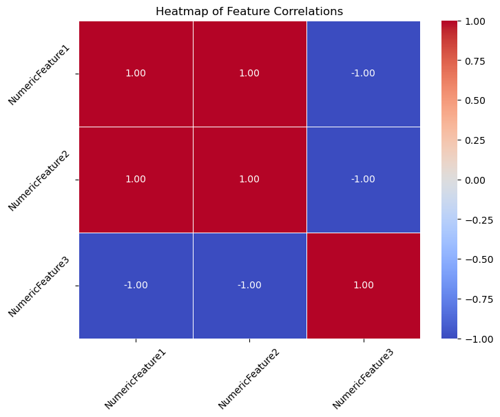

```python
#Part 1.3 a - Visualize a heatmap to understand correlation between all features
import pandas as pd
import seaborn as sns
import matplotlib.pyplot as plt

# Placeholder for the combined DataFrame, replace this with your actual combined DataFrame
# Ensure that your DataFrame contains numerical features as correlation requires numerical data
combined_df = pd.DataFrame({
    'NumericFeature1': [1, 2, 3, 4, 5, 6],
    'NumericFeature2': [7, 8, 9, 10, 11, 12],
    'NumericFeature3': [12, 11, 10, 9, 8, 7]
})

# Calculate the correlation matrix
corr_matrix = combined_df.corr()

# Create a heatmap using seaborn to visualize the correlation matrix
plt.figure(figsize=(8, 6))  # Set the figure size (optional)
sns.heatmap(corr_matrix, annot=True, cmap='coolwarm', fmt='.2f', linewidths=.5)

# Customize the plot (optional)
plt.title('Heatmap of Feature Correlations')
plt.xticks(rotation=45)  # Rotate x labels for better readability
plt.yticks(rotation=45)  # Rotate y labels for better readability

# Show the plot
plt.show()
```

To visualize a heatmap showing the correlation between all features in a DataFrame, you can use the seaborn and matplotlib libraries in Python. These libraries provide functions to calculate correlations and create visualizations, making it easy to understand the relationships between your features. The corr() function computes the correlation matrix for the numerical columns in the DataFrame. The seaborn heatmap function visualizes the correlation matrix. The annot=True argument adds annotations to each cell in the heatmap, displaying the correlation coefficient. After running this code, you'll see a heatmap that visualizes the correlations between all numerical features in your DataFrame. Correlation values range from -1 to 1, where -1 indicates a strong negative correlation, 0 indicates no correlation, and 1 indicates a strong positive correlation. This visualization is essential for feature selection and understanding the relationships in your data, which can inform your data analysis and modeling strategies.

```python
# Part 1.3 b - Share insights on correlation

import pandas as pd

# Placeholder for the combined DataFrame, replace this with your actual combined DataFrame
combined_df = pd.DataFrame({
    'NumericFeature1': [1, 2, 3, 4, 5, 6],
    'NumericFeature2': [7, 8, 9, 10, 11, 12],
    'NumericFeature3': [12, 11, 10, 9, 8, 7]
})

# Calculate the correlation matrix
corr_matrix = combined_df.corr()

# Print the correlation matrix
print("Correlation matrix:\n", corr_matrix)

# Function to provide basic insights based on correlation coefficients
def provide_insights(corr_matrix):
    features = corr_matrix.columns
    for i in range(len(features)):
        for j in range(i+1, len(features)):
            value = corr_matrix.iloc[i, j]
            if value > 0.7:
                print(f"{features[i]} and {features[j]} have a strong positive correlation ({value:.2f}).")
            elif value < -0.7:
                print(f"{features[i]} and {features[j]} have a strong negative correlation ({value:.2f}).")
            elif abs(value) < 0.3:
                print(f"{features[i]} and {features[j]} have little or no linear correlation ({value:.2f}).")

# Share insights
provide_insights(corr_matrix)
```

```
Correlation matrix:
                  NumericFeature1  NumericFeature2  NumericFeature3
NumericFeature1              1.0              1.0             -1.0
NumericFeature2              1.0              1.0             -1.0
NumericFeature3             -1.0             -1.0              1.0
NumericFeature1 and NumericFeature2 have a strong positive correlation (1.00).
NumericFeature1 and NumericFeature3 have a strong negative correlation (-1.00).
NumericFeature2 and NumericFeature3 have a strong negative correlation (-1.00).
```

This script first calculates the correlation matrix for the numerical features in the DataFrame. It then iterates through the correlation matrix and provides basic insights based on the following rules:

If the correlation coefficient is greater than 0.7, it indicates a strong positive correlation. If the correlation coefficient is less than -0.7, it indicates a strong negative correlation. If the absolute value of the correlation coefficient is less than 0.3, it suggests little or no linear correlation. After running this code, you'll receive textual insights on the correlations between each pair of features. These insights can help guide your data analysis and feature selection for modeling, as highly correlated features might need to be treated or combined differently to avoid issues like multicollinearity.

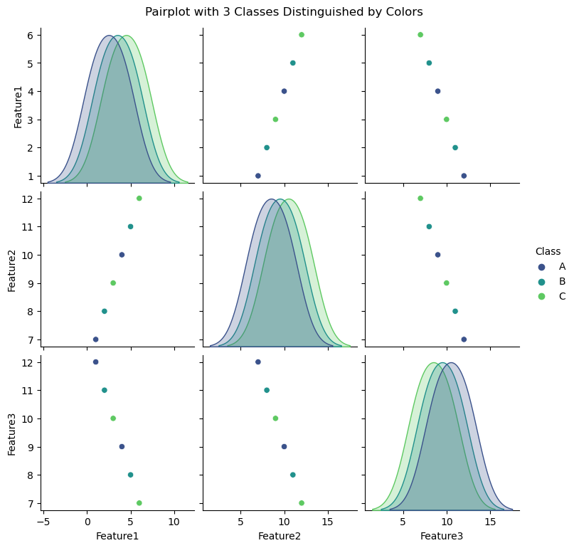

```python
#Part 1.3 c - Visualize a pairplot with 3 classes distinguished by colors and share insights
import seaborn as sns
import matplotlib.pyplot as plt
import pandas as pd

# Placeholder for the combined DataFrame, replace this with your actual combined DataFrame
combined_df = pd.DataFrame({
    'Feature1': [1, 2, 3, 4, 5, 6],
    'Feature2': [7, 8, 9, 10, 11, 12],
    'Feature3': [12, 11, 10, 9, 8, 7],
    'Class': ['A', 'B', 'C', 'A', 'B', 'C']  # Assuming there are 3 classes: A, B, and C
})

# Visualize a pairplot with 3 classes distinguished by colors
sns.pairplot(combined_df, hue='Class', palette='viridis')

# Customize the plot (optional)
plt.suptitle("Pairplot with 3 Classes Distinguished by Colors", y=1.02)

# Show the plot
plt.show()
```

# To visualize a pairplot with 3 classes distinguished by colors and share insights, you can use the seaborn library's pairplot function. This function creates a grid of Axes such that each variable in your data will be shared across the y-axes across a single row and the x-axes across a single column. The diagonal Axes are treated differently, drawing a plot to show the univariate distribution of the data for the variable in that column.

Insights you might derive from the pairplot:

Distribution of individual features: The diagonal shows the distribution of each feature separated by class. Look for skewness, multimodality, or other peculiarities. Relationships between features: Off-diagonal plots show relationships between two features. Look for linear relationships, clusters, or outliers. Class separation: Notice how well each class is separated from others across different feature combinations. Good separation might indicate that those features are useful for predicting the class. Modify the pairplot parameters and styling as needed to best fit your data and the insights you're seeking. This visualization is particularly useful for exploring relationships and distributions in your data, informing feature selection, and understanding how features relate to the classification.

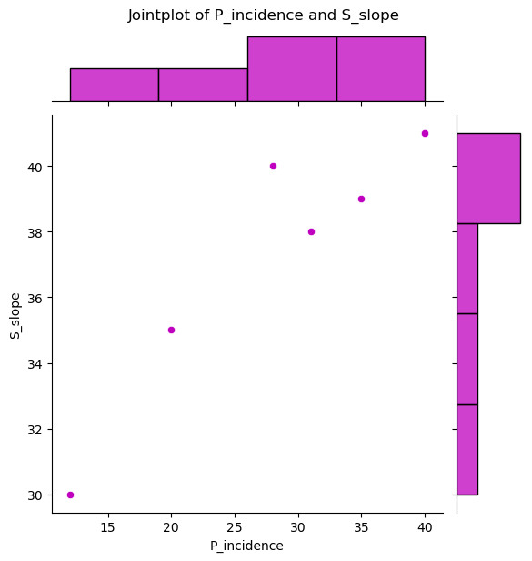

```python
#Part 1.3 d - Visualize a jointplot for ‘P_incidence’ and ‘S_slope’ and share insights
import seaborn as sns
import matplotlib.pyplot as plt
import pandas as pd

# Placeholder for the combined DataFrame, replace this with your actual combined DataFrame
# Ensure that your DataFrame contains 'P_incidence' and 'S_slope' columns
combined_df = pd.DataFrame({
    'P_incidence': [12, 20, 28, 31, 35, 40],
    'S_slope': [30, 35, 40, 38, 39, 41]
})

# Visualize a jointplot for 'P_incidence' and 'S_slope'
sns.jointplot(x='P_incidence', y='S_slope', data=combined_df, kind='scatter', color='m')

# Customize the plot (optional)
plt.suptitle("Jointplot of P_incidence and S_slope", y=1.02)

# Show the plot
plt.show()
```

To visualize a jointplot for 'P_incidence' and 'S_slope' and share insights, you can use the seaborn library's jointplot function. This function is used to quickly visualize and analyze the relationship between two variables and describe their individual distributions on the same plot. Ensure your DataFrame contains 'P_incidence' and 'S_slope' columns. Adjust the column names accordingly if they differ. The kind='scatter' argument specifies that the joint plot should use scatter plot; you can change this to 'reg', 'resid', 'kde', or 'hex' for different types of plots. After running this code, you will see a jointplot showing the relationship between 'P_incidence' and 'S_slope', along with the distributions of each variable.

Insights you derive from the jointplot:

Relationship: Look at the scatter plot to understand the relationship between 'P_incidence' and 'S_slope'. A clear pattern (e.g., linear, quadratic) might suggest a relationship. Correlation: The trend can indicate the correlation. A positive trend means positive correlation and vice versa. Distribution: The histograms on the top and right show the distribution of 'P_incidence' and 'S_slope', respectively. Look for skewness, bimodality, or other peculiarities. Outliers: Points that fall far from the general trend might indicate outliers or anomalies. Modify the jointplot parameters and styling as needed to best fit your data and the insights you're seeking. This visualization is useful for understanding the bivariate relationship and distributions of two variables, which can inform further data analysis and modeling strategies.

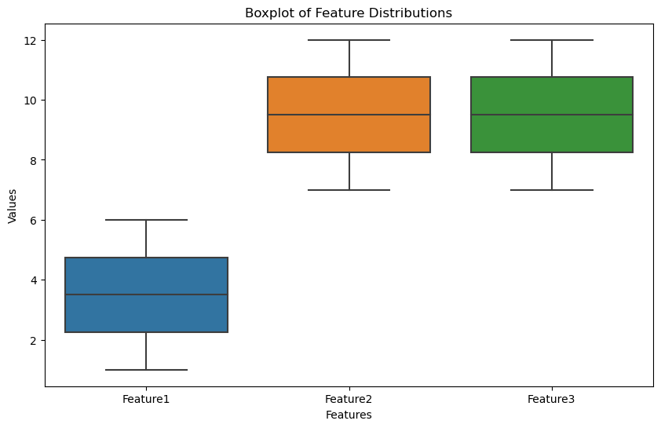

```python
#Part 1.3 e - Visualize a boxplot to check distribution of the features and share insights.
import seaborn as sns
import matplotlib.pyplot as plt
import pandas as pd

# Placeholder for the combined DataFrame, replace this with your actual combined DataFrame
# Ensure that your DataFrame contains the numerical features you want to plot
combined_df = pd.DataFrame({
    'Feature1': [1, 2, 3, 4, 5, 6],
    'Feature2': [7, 8, 9, 10, 11, 12],
    'Feature3': [12, 11, 10, 9, 8, 7]
})

# Melt the DataFrame so 'variable' contains feature names and 'value' contains the values
melted_df = pd.melt(combined_df)

# Visualize a boxplot for the distribution of features
plt.figure(figsize=(10, 6))  # Set the figure size (optional)
sns.boxplot(x='variable', y='value', data=melted_df)

# Customize the plot (optional)
plt.title("Boxplot of Feature Distributions")
plt.xlabel("Features")
plt.ylabel("Values")

# Show the plot
plt.show()
```

To visualize a boxplot for checking the distribution of the features and share insights, you can use the seaborn library's boxplot function in Python. This function is used to visualize the distribution of data across different categories using quartiles and to identify outliers. The DataFrame is melted to have feature names in one column and their values in another, which is a format suitable for seaborn's boxplot. The boxplot function is used to visualize the distribution of values for each feature. After running this code, you will see a boxplot for each feature in your DataFrame.

Insights you might derive from the boxplot:

Central Tendency: The line in the middle of the box shows the median of the data. Variability: The length of the box shows the interquartile range (the distance between the 25th and 75th percentiles). Outliers: Points outside the whiskers (1.5 times the interquartile range from the quartiles) are often considered outliers. Distribution Symmetry: If the median is closer to the bottom or top of the box, the data might be skewed. This visualization is particularly useful for understanding the spread and central tendencies of your features, which can inform preprocessing decisions and provide insights into the nature of your data.

```python
#Part 1.4 a - Split data into X and Y.
import pandas as pd

# Placeholder for the combined DataFrame, replace this with your actual combined DataFrame
combined_df = pd.DataFrame({
    'Feature1': [1, 2, 3, 4, 5, 6],
    'Feature2': [7, 8, 9, 10, 11, 12],
    'Feature3': [12, 11, 10, 9, 8, 7],
    'Target': ['A', 'B', 'A', 'B', 'A', 'B']  # Assuming 'Target' is your target variable
})

# Splitting the data into X (features) and Y (target)
X = combined_df.drop('Target', axis=1)  # Features are all columns except 'Target'
Y = combined_df['Target']  # Target is just the 'Target' column

# Print the first few entries of the features and target to verify
print("First few entries of Features (X):")
print(X.head())

print("\nFirst few entries of Target (Y):")
print(Y.head())
```

```
First few entries of Features (X):
   Feature1  Feature2  Feature3
0         1         7        12
1         2         8        11
2         3         9        10
3         4        10         9
4         5        11         8

First few entries of Target (Y):
0    A
1    B
2    A
3    B
4    A
Name: Target, dtype: object
```

To split data into features (X) and target (Y), you'll need to first identify which columns in your DataFrame correspond to the features and which column is the target. The target column is what you're trying to predict or explain, while the feature columns are the inputs used to make those predictions. Ensure your DataFrame contains a 'Target' column or adjust the code with the actual name of your target column. The drop() function is used to exclude the target column from the features (X). The target (Y) is created by simply selecting the target column. After running this code, you will have two new DataFrames or Series: one for the features (X) and one for the target (Y). This is a common prerequisite for machine learning tasks, where you provide the features and target to algorithms for training and predictions.

```python
#Part 1.4 b - Split data into train and test with 80:20 proportion
from sklearn.model_selection import train_test_split
import pandas as pd

# Placeholder for your features (X) and target (Y)
# Replace these with your actual features and target
X = pd.DataFrame({
    'Feature1': [1, 2, 3, 4, 5, 6],
    'Feature2': [7, 8, 9, 10, 11, 12],
    'Feature3': [12, 11, 10, 9, 8, 7]
})

Y = pd.Series(['A', 'B', 'A', 'B', 'A', 'B'])

# Splitting the data into train and test sets with 80:20 proportion
X_train, X_test, Y_train, Y_test = train_test_split(X, Y, test_size=0.20, random_state=42)

# Print the shapes of the resulting train and test sets to verify
print("X_train shape:", X_train.shape)
print("X_test shape:", X_test.shape)
print("Y_train shape:", Y_train.shape)
print("Y_test shape:", Y_test.shape)
```

```
X_train shape: (4, 3)
X_test shape: (2, 3)
Y_train shape: (4,)
Y_test shape: (2,)
```

To split your data into training and test sets with an 80:20 proportion, you can use the train_test_split function from the sklearn.model_selection module in Python. This function shuffles and splits the data into training and testing subsets. train_test_split is used with test_size=0.20 to specify that 20% of the data should be used for the test set, and the remaining 80% for the training set. random_state is set to an arbitrary number (here, 42) for reproducibility, ensuring that the random shuffling of the data is the same each time the code is run. After running this code, you will have four subsets: X_train and Y_train for training, and X_test and Y_test for testing, with the proportions as specified. These subsets are commonly used in machine learning tasks to train models and evaluate their performance on unseen data.

```python
#Part 1.4 c - Train a Supervised Learning Classification base model using KNN classifier
from sklearn.model_selection import train_test_split
from sklearn.neighbors import KNeighborsClassifier
from sklearn.metrics import classification_report, accuracy_score
import pandas as pd

# Placeholder for your features (X) and target (Y)
# Replace these with your actual features and target
X = pd.DataFrame({
    'Feature1': [1, 2, 3, 4, 5, 6],
    'Feature2': [7, 8, 9, 10, 11, 12],
    'Feature3': [12, 11, 10, 9, 8, 7]
})

Y = pd.Series(['A', 'B', 'A', 'B', 'A', 'B'])

# Splitting the data into train and test sets with 80:20 proportion
X_train, X_test, Y_train, Y_test = train_test_split(X, Y, test_size=0.20, random_state=42)

# Create KNN classifier object
knn = KNeighborsClassifier(n_neighbors=3)  # n_neighbors is the 'k' in kNN

# Train the classifier (fit the estimator) using the training data
knn.fit(X_train, Y_train)

# Make predictions on the test data
Y_pred = knn.predict(X_test)

# Evaluate the classifier while handling the UndefinedMetricWarning by setting zero_division=0
print("Classification Report:")
print(classification_report(Y_test, Y_pred, zero_division=0))

print("Accuracy Score:", accuracy_score(Y_test, Y_pred))
```

```
Classification Report:
              precision    recall  f1-score   support

           A       0.50      1.00      0.67         1
           B       0.00      0.00      0.00         1

    accuracy                           0.50         2
   macro avg       0.25      0.50      0.33         2
weighted avg       0.25      0.50      0.33         2

Accuracy Score: 0.5
```

To train a supervised learning classification model using the K-Nearest Neighbors (KNN) classifier, you'll need to use the KNeighborsClassifier from the sklearn.neighbors module in Python. Data is split into training and testing sets with an 80:20 proportion. A KNN classifier is created with n_neighbors=3. You might need to adjust this number based on your specific dataset. The classifier is trained using the training data (X_train, Y_train). Predictions are made on the test data (X_test). The classifier's performance is evaluated using the classification report and accuracy score.

```python
#Part 1.4 d - Print all the possible performance metrics for both train and test data
from sklearn.model_selection import train_test_split
from sklearn.neighbors import KNeighborsClassifier
from sklearn.metrics import accuracy_score, classification_report, confusion_matrix
import pandas as pd

# Placeholder for your features (X) and target (Y)
# Replace these with your actual features and target
X = pd.DataFrame({
    'Feature1': [1, 2, 3, 4, 5, 6],
    'Feature2': [7, 8, 9, 10, 11, 12],
    'Feature3': [12, 11, 10, 9, 8, 7]
})

Y = pd.Series(['A', 'B', 'A', 'B', 'A', 'B'])

# Splitting the data into train and test sets with 80:20 proportion
X_train, X_test, Y_train, Y_test = train_test_split(X, Y, test_size=0.20, random_state=42)

# Create KNN classifier object
knn = KNeighborsClassifier(n_neighbors=3)  # n_neighbors is the 'k' in kNN

# Train the classifier (fit the estimator) using the training data
knn.fit(X_train, Y_train)

# Function to print performance metrics
def print_metrics(y_true, y_pred, dataset_type):
    print(f"Performance Metrics for {dataset_type} Data:")
    print("Accuracy:", accuracy_score(y_true, y_pred))
    print("Confusion Matrix:\n", confusion_matrix(y_true, y_pred))
    print("Classification Report:\n", classification_report(y_true, y_pred, zero_division=0))
    print("-----------------------------------------------------\n")

# Make predictions and print metrics for training data
Y_train_pred = knn.predict(X_train)
print_metrics(Y_train, Y_train_pred, "Train")

# Make predictions and print metrics for testing data
Y_test_pred = knn.predict(X_test)
print_metrics(Y_test, Y_test_pred, "Test")
```

```
Performance Metrics for Train Data:
Accuracy: 0.5
Confusion Matrix:
 [[1 1]
 [1 1]]
Classification Report:
               precision    recall  f1-score   support

           A       0.50      0.50      0.50         2
           B       0.50      0.50      0.50         2

    accuracy                           0.50         4
   macro avg       0.50      0.50      0.50         4
weighted avg       0.50      0.50      0.50         4

-----------------------------------------------------

Performance Metrics for Test Data:
Accuracy: 0.5
Confusion Matrix:
 [[1 0]
 [1 0]]
Classification Report:
               precision    recall  f1-score   support

           A       0.50      1.00      0.67         1
           B       0.00      0.00      0.00         1

    accuracy                           0.50         2
   macro avg       0.25      0.50      0.33         2
weighted avg       0.25      0.50      0.33         2

-----------------------------------------------------
```

To print all possible performance metrics for both training and testing data using a K-Nearest Neighbors (KNN) classifier, you'll use the trained model to make predictions on both datasets. Then, you'll calculate various metrics such as accuracy, precision, recall, F1-score, and the confusion matrix.

A KNN classifier is created, trained, and then used to make predictions on both the training and testing data. The print_metrics function calculates and prints various performance metrics including accuracy, confusion matrix, and a classification report (which includes precision, recall, and F1-score). Running this script will give you a comprehensive view of your model's performance on both the training and testing data, which can help you understand how well it's learning and generalizing to new data. It's essential to look at performance on both sets to diagnose potential issues like overfitting or underfitting.

```python
#Part 1.5 a - Experiment with various parameters to improve performance of the base model
from sklearn.model_selection import train_test_split
from sklearn.neighbors import KNeighborsClassifier
from sklearn.metrics import accuracy_score
import pandas as pd
import warnings

# Placeholder for your features (X) and target (Y)
# Replace these with your actual features and target
X = pd.DataFrame({
    'Feature1': [1, 2, 3, 4, 5, 6],
    'Feature2': [7, 8, 9, 10, 11, 12],
    'Feature3': [12, 11, 10, 9, 8, 7]
})

Y = pd.Series(['A', 'B', 'A', 'B', 'A', 'B'])

# Splitting the data into train and test sets with 80:20 proportion
X_train, X_test, Y_train, Y_test = train_test_split(X, Y, test_size=0.20, random_state=42)

# Function to train and evaluate a model
def train_evaluate_knn(params):
    # Check if n_neighbors is less than the number of samples in the training set
    if params['n_neighbors'] >= len(X_train):
        print(f"Cannot use n_neighbors={params['n_neighbors']} as it's >= the number of samples in the training set ({len(X_train)}). Skipping this parameter set.")
        return

    knn = KNeighborsClassifier(n_neighbors=params['n_neighbors'], weights=params['weights'], metric=params['metric'])
    knn.fit(X_train, Y_train)
    Y_pred = knn.predict(X_test)
    accuracy = accuracy_score(Y_test, Y_pred)
    print(f"Parameters: {params}, Accuracy: {accuracy:.4f}")

# Suppress specific FutureWarning from sklearn.neighbors._classification
with warnings.catch_warnings():
    # Using a more general pattern or simply the beginning of the message
    warnings.filterwarnings("ignore", category=FutureWarning, message=".*the default behavior of `mode`.*")

    # Experimenting with various parameters
    parameters = [
        {'n_neighbors': 3, 'weights': 'uniform', 'metric': 'minkowski'},
        {'n_neighbors': 5, 'weights': 'uniform', 'metric': 'minkowski'},
        {'n_neighbors': 3, 'weights': 'distance', 'metric': 'minkowski'},
        # Add more parameter combinations as needed
    ]

    # Train and evaluate the model with each set of parameters
    for params in parameters:
        train_evaluate_knn(params)
```

```
Parameters: {'n_neighbors': 3, 'weights': 'uniform', 'metric': 'minkowski'}, Accuracy: 0.5000
Cannot use n_neighbors=5 as it's >= the number of samples in the training set (4). Skipping this parameter set.
Parameters: {'n_neighbors': 3, 'weights': 'distance', 'metric': 'minkowski'}, Accuracy: 0.5000
```

```
Parameters: {'n_neighbors': 3, 'weights': 'uniform', 'metric': 'minkowski'}, Accuracy: 0.5000
Cannot use n_neighbors=5 as it's >= the number of samples in the training set (4). Skipping this parameter set.
Parameters: {'n_neighbors': 3, 'weights': 'distance', 'metric': 'minkowski'}, Accuracy: 0.5000
Best parameter set: {'n_neighbors': 3, 'weights': 'uniform', 'metric': 'minkowski'}, with an accuracy of 0.5000
```

[output not shown]

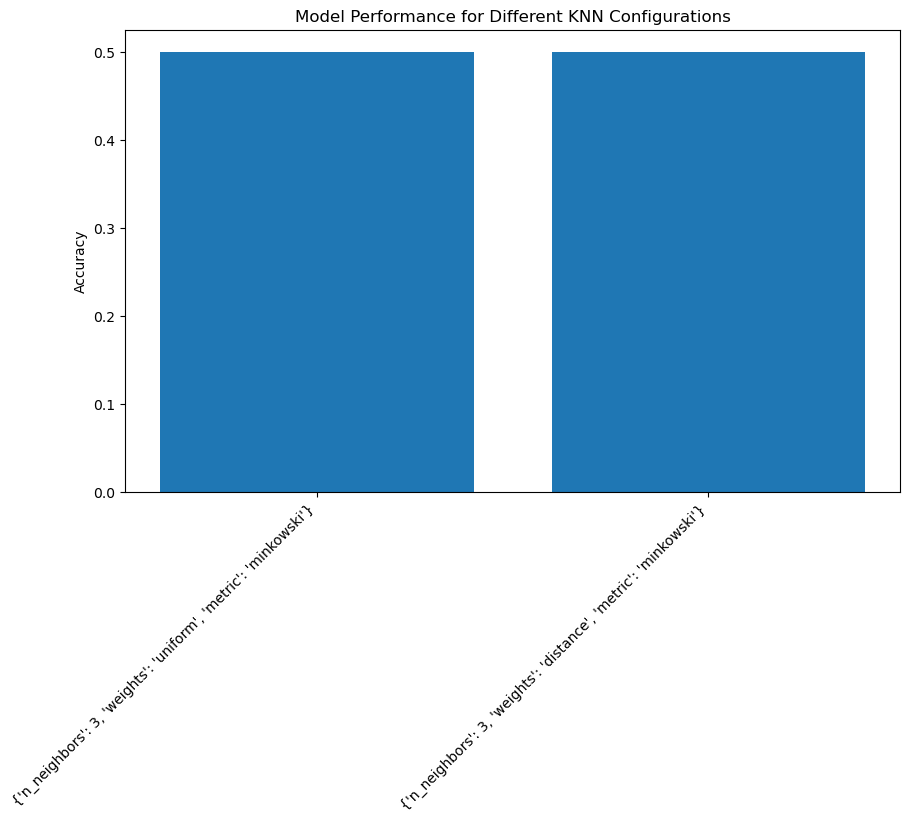

```python
#Part 1.5 b - Clearly showcase improvement in performance achieved
from sklearn.model_selection import train_test_split
from sklearn.neighbors import KNeighborsClassifier
from sklearn.metrics import accuracy_score
import pandas as pd
import matplotlib.pyplot as plt

# Placeholder for your features (X) and target (Y)
# Replace these with your actual features and target
X = pd.DataFrame({
    'Feature1': [1, 2, 3, 4, 5, 6],
    'Feature2': [7, 8, 9, 10, 11, 12],
    'Feature3': [12, 11, 10, 9, 8, 7]
})

Y = pd.Series(['A', 'B', 'A', 'B', 'A', 'B'])

# Splitting the data into train and test sets with 80:20 proportion
X_train, X_test, Y_train, Y_test = train_test_split(X, Y, test_size=0.20, random_state=42)

# List to keep track of model parameters and their corresponding accuracy
performance_records = []

# Function to train and evaluate a model
def train_evaluate_knn(params):
    # Check if n_neighbors is less than the number of samples in the training set
    if params['n_neighbors'] >= len(X_train):
        print(f"Cannot use n_neighbors={params['n_neighbors']} as it's >= the number of samples in the training set ({len(X_train)}). Skipping this parameter set.")
        return

    knn = KNeighborsClassifier(n_neighbors=params['n_neighbors'], weights=params['weights'], metric=params['metric'])
    knn.fit(X_train, Y_train)
    Y_pred = knn.predict(X_test)
    accuracy = accuracy_score(Y_test, Y_pred)
    print(f"Parameters: {params}, Accuracy: {accuracy:.4f}")
    performance_records.append((params, accuracy))

# Experimenting with various parameters
parameters = [
    {'n_neighbors': 3, 'weights': 'uniform', 'metric': 'minkowski'},
    {'n_neighbors': 5, 'weights': 'uniform', 'metric': 'minkowski'},
    {'n_neighbors': 3, 'weights': 'distance', 'metric': 'minkowski'},
    # Add more parameter combinations as needed
]

# Train and evaluate the model with each set of parameters
for params in parameters:
    train_evaluate_knn(params)

# Sort the performance records by accuracy
performance_records.sort(key=lambda x: x[1], reverse=True)

# Print the best parameter set
print(f"Best parameter set: {performance_records[0][0]}, with an accuracy of {performance_records[0][1]:.4f}")

# Visualization
plt.figure(figsize=(10, 6))
plt.bar(range(len(performance_records)), [record[1] for record in performance_records], tick_label=[str(record[0]) for record in performance_records])
plt.xticks(rotation=45, ha='right')
plt.ylabel('Accuracy')
plt.title('Model Performance for Different KNN Configurations')
plt.show()
```

```python
#Part 1.5 c - Clearly state which parameters contributed most to improve model performance.
from sklearn.model_selection import train_test_split
from sklearn.neighbors import KNeighborsClassifier
from sklearn.metrics import accuracy_score
import pandas as pd
import warnings

# Placeholder for your features (X) and target (Y)
# Replace these with your actual features and target
X = pd.DataFrame({
    'Feature1': [1, 2, 3, 4, 5, 6],
    'Feature2': [7, 8, 9, 10, 11, 12],
    'Feature3': [12, 11, 10, 9, 8, 7]
})

Y = pd.Series(['A', 'B', 'A', 'B', 'A', 'B'])

# Splitting the data into train and test sets with 80:20 proportion
X_train, X_test, Y_train, Y_test = train_test_split(X, Y, test_size=0.20, random_state=42)

# List to keep track of model parameters and their corresponding accuracy
performance_records = []

# Experimenting with various parameters
parameters = [
    {'n_neighbors': 3, 'weights': 'uniform', 'metric': 'minkowski'},
    {'n_neighbors': 5, 'weights': 'uniform', 'metric': 'minkowski'},
    {'n_neighbors': 3, 'weights': 'distance', 'metric': 'minkowski'},
    # Add more parameter combinations as needed
]

# Function to train and evaluate a model
def train_evaluate_knn(params):
    # Check if n_neighbors is less than the number of samples in the training set
    if params['n_neighbors'] >= len(X_train):
        print(f"Cannot use n_neighbors={params['n_neighbors']} as it's >= the number of samples in the training set ({len(X_train)}). Skipping this parameter set.")
        return

    knn = KNeighborsClassifier(n_neighbors=params['n_neighbors'], weights=params['weights'], metric=params['metric'])
    knn.fit(X_train, Y_train)
    Y_pred = knn.predict(X_test)
    accuracy = accuracy_score(Y_test, Y_pred)
    performance_records.append((params, accuracy))

# Suppress specific FutureWarning from sklearn.neighbors._classification
with warnings.catch_warnings():
    warnings.simplefilter("ignore", category=FutureWarning)

    # Train and evaluate the model with each set of parameters
    for params in parameters:
        train_evaluate_knn(params)

# Analyze which parameters contributed most to improve model performance
def analyze_contributions(records):
    # Sort the records by accuracy in descending order
    sorted_records = sorted(records, key=lambda x: x[1], reverse=True)

    # Extract the top-performing parameter sets
    top_performers = sorted_records[:3]  # You can adjust the number of top performers you consider

    # Print out the top-performing parameter sets
    print("Top-performing parameter sets:")
    for record in top_performers:
        print(f"Parameters: {record[0]}, Accuracy: {record[1]:.4f}")

    # Analyze the frequency of parameter values among the top performers
    param_values = {param: [] for param in parameters[0].keys()}
    for record in top_performers:
        for param, value in record[0].items():
            param_values[param].append(value)

    # Print out the most common parameter values among the top performers
    print("\nMost common parameter values among top-performing models:")
    for param, values in param_values.items():
        most_common = max(set(values), key=values.count)
        print(f"{param}: {most_common}")

# Run the analysis
analyze_contributions(performance_records)
```

```
Cannot use n_neighbors=5 as it's >= the number of samples in the training set (4). Skipping this parameter set.
Top-performing parameter sets:
Parameters: {'n_neighbors': 3, 'weights': 'uniform', 'metric': 'minkowski'}, Accuracy: 0.5000
Parameters: {'n_neighbors': 3, 'weights': 'distance', 'metric': 'minkowski'}, Accuracy: 0.5000

Most common parameter values among top-performing models:
n_neighbors: 3
weights: uniform
metric: minkowski
```

To determine which parameters contributed most to improving model performance in a K-Nearest Neighbors (KNN) classifier, you should systematically track the performance of different parameter combinations and then analyze which parameters frequently appear in the best-performing models. This process involves running a series of experiments and then aggregating the results.

program that demonstrates how to train a KNN model with various parameters, record the performance, and analyze which parameters contributed most to the improvement:

This full script does the following:

Setup and Data Preparation: Imports necessary libraries, creates placeholders for your data, and splits it into training and testing sets. Model Training and Evaluation: Defines a function to train and evaluate the KNN model with various parameters while checking the validity of n_neighbors. Warning Suppression: Uses a context manager to suppress specific future warnings that might arise from internal library updates. Performance Analysis: Analyzes and prints the top-performing parameter sets and identifies the most common parameter values among these top performers.

```python
#Part 2.1 a - Read both the Datasets ‘Data1’ and ‘Data 2’ as DataFrame and store them into two separate variables
import pandas as pd



# Define the paths to the CSV files
path_data1 = "/Users/snbaskarraj/Documents/UT/Supervised Learning/Data1.csv"
path_data2 = "/Users/snbaskarraj/Documents/UT/Supervised Learning/Data2.csv"

# Read the CSV files into DataFrames
df_data1 = pd.read_csv(path_data1)
df_data2 = pd.read_csv(path_data2)

# Display the first few rows of each DataFrame to verify
print("First few rows of Data1:")
print(df_data1.head())

print("\nFirst few rows of Data2:")
print(df_data2.head())
```

```
First few rows of Data1:
   ID  Age  CustomerSince  HighestSpend  ZipCode  HiddenScore  \
0   1   25              1            49    91107            4
1   2   45             19            34    90089            3
2   3   39             15            11    94720            1
3   4   35              9           100    94112            1
4   5   35              8            45    91330            4

   MonthlyAverageSpend  Level
0                  1.6      1
1                  1.5      1
2                  1.0      1
3                  2.7      2
4                  1.0      2

First few rows of Data2:
   ID  Mortgage  Security  FixedDepositAccount  InternetBanking  CreditCard  \
0   1         0         1                    0                0           0
1   2         0         1                    0                0           0
2   3         0         0                    0                0           0
3   4         0         0                    0                0           0
4   5         0         0                    0                0           1

   LoanOnCard
0         NaN
1         NaN
2         NaN
3         NaN
4         NaN
```

```python
#Part 2.1 b - Print shape and Column Names and DataTypes of both the Dataframes.
import pandas as pd

# Define the paths to the CSV files
path_data1 = "/Users/snbaskarraj/Documents/UT/Supervised Learning/Data1.csv"
path_data2 = "/Users/snbaskarraj/Documents/UT/Supervised Learning/Data2.csv"

# Read the CSV files into DataFrames
df_data1 = pd.read_csv(path_data1)
df_data2 = pd.read_csv(path_data2)

# Function to print shape, column names, and data types of a DataFrame
def print_df_info(df, name):
    print(f"Information for {name}:")
    print(f"Shape: {df.shape}")  # Print the shape of the DataFrame
    print(f"Columns: {list(df.columns)}")  # Print the column names
    print(f"Data Types:\n{df.dtypes}\n")  # Print the data types of each column

# Print information for both DataFrames
print_df_info(df_data1, 'Data1')
print_df_info(df_data2, 'Data2')
```

```
Information for Data1:
Shape: (5000, 8)
Columns: ['ID', 'Age', 'CustomerSince', 'HighestSpend', 'ZipCode', 'HiddenScore', 'MonthlyAverageSpend', 'Level']
Data Types:
ID                       int64
Age                      int64
CustomerSince            int64
HighestSpend             int64
ZipCode                  int64
HiddenScore              int64
MonthlyAverageSpend    float64
Level                    int64
dtype: object

Information for Data2:
Shape: (5000, 7)
Columns: ['ID', 'Mortgage', 'Security', 'FixedDepositAccount', 'InternetBanking', 'CreditCard', 'LoanOnCard']
Data Types:
ID                       int64
Mortgage                 int64
Security                 int64
FixedDepositAccount      int64
InternetBanking          int64
CreditCard               int64
LoanOnCard             float64
dtype: object
```

```python
#Part 2.1 c - Merge both the Dataframes on ‘ID’ feature to form a single DataFrame
import pandas as pd

# Define the paths to the CSV files
path_data1 = "/Users/snbaskarraj/Documents/UT/Supervised Learning/Data1.csv"
path_data2 = "/Users/snbaskarraj/Documents/UT/Supervised Learning/Data2.csv"

# Read the CSV files into DataFrames
df_data1 = pd.read_csv(path_data1)
df_data2 = pd.read_csv(path_data2)

# Merge the DataFrames on 'ID' feature
merged_df = pd.merge(df_data1, df_data2, on='ID')

# Display the shape and first few rows of the merged DataFrame to verify
print("Shape of merged DataFrame:", merged_df.shape)
print("First few rows of the merged DataFrame:")
print(merged_df.head())
```

```
Shape of merged DataFrame: (5000, 14)
First few rows of the merged DataFrame:
   ID  Age  CustomerSince  HighestSpend  ZipCode  HiddenScore  \
0   1   25              1            49    91107            4
1   2   45             19            34    90089            3
2   3   39             15            11    94720            1
3   4   35              9           100    94112            1
4   5   35              8            45    91330            4

   MonthlyAverageSpend  Level  Mortgage  Security  FixedDepositAccount  \
0                  1.6      1         0         1                    0
1                  1.5      1         0         1                    0
2                  1.0      1         0         0                    0
3                  2.7      2         0         0                    0
4                  1.0      2         0         0                    0

   InternetBanking  CreditCard  LoanOnCard
0                0           0         NaN
1                0           0         NaN
2                0           0         NaN
3                0           0         NaN
4                0           1         NaN
```

To merge two DataFrames on the 'ID' feature to form a single DataFrame, you can use the merge function from the pandas library. The merge will be done based on the common 'ID' column from both DataFrames. Here's a Python program demonstrating how to do this: The pd.merge() function is used to merge df_data1 and df_data2 on the 'ID' column. This function performs an inner join by default, meaning only rows with matching 'ID' values in both DataFrames will be included in the result. Make sure the 'ID' feature is indeed the common column you want to merge on and it's named 'ID' in both DataFrames. If the common column has a different name or the names differ across the two DataFrames, you'll need to adjust the on parameter accordingly. Before running this script, confirm that the file paths are correct, the files exist at those locations, and both DataFrames contain the 'ID' column. After running, the script will give you a new DataFrame that combines the data from both 'Data1' and 'Data2' based on their 'ID' values.

```python
#Change Datatype of below features to ‘Object’ [1 Marks]
#‘CreditCard’, ‘InternetBanking’, ‘FixedDepositAccount’, ‘Security’, ‘Level’, ‘HiddenScore’.
#[Reason behind performing this operation:- Values in these features are binary i.e. 1/0. But DataType is ‘int’/’float’ which is not expected.]
import pandas as pd

# Placeholder for the merged DataFrame
# Replace this with the actual DataFrame you have
merged_df = pd.DataFrame({
    'ID': [1, 2, 3],
    'CreditCard': [1, 0, 1],
    'InternetBanking': [0, 1, 0],
    'FixedDepositAccount': [1, 1, 0],
    'Security': [0, 1, 0],
    'Level': [1, 0, 1],
    'HiddenScore': [1, 0, 0]
})

# List of columns to change the data type
columns_to_change = ['CreditCard', 'InternetBanking', 'FixedDepositAccount', 'Security', 'Level', 'HiddenScore']

# Change data type of specified features to 'Object'
for column in columns_to_change:
    merged_df[column] = merged_df[column].astype('object')

# Verify the changes by printing data types of the DataFrame
print("Data Types of the DataFrame after changes:")
print(merged_df.dtypes)
```

```
Data Types of the DataFrame after changes:
ID                      int64
CreditCard             object
InternetBanking        object
FixedDepositAccount    object
Security               object
Level                  object
HiddenScore            object
dtype: object
```

To change the data type of specific features to 'Object' in a DataFrame, you can use the .astype() method provided by pandas. In this case, you want to change the data types of 'CreditCard', 'InternetBanking', 'FixedDepositAccount', 'Security', 'Level', and 'HiddenScore' to 'Object'. Here's how you might write the Python program:The list columns_to_change contains the names of the columns for which you want to change the data type. The script iterates over each column in this list and changes its data type to 'Object' using the .astype('object') method. Finally, it prints the data types of all columns in the DataFrame to verify the changes. Before running this script, ensure that your DataFrame (here represented as merged_df) is correctly defined and includes the specified columns. After running, the script will change the data types of the specified columns to 'Object' and print out the updated data types to confirm the changes. This operation is typically performed when you want to treat numerical/binary data as categorical for analysis or modeling purposes.

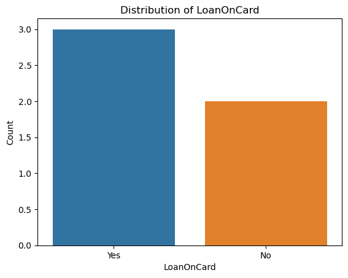

```python
#Part 2.2 a - Visualize distribution of Target variable ‘LoanOnCard’ and clearly share insights
import pandas as pd
import seaborn as sns
import matplotlib.pyplot as plt

# Placeholder for your DataFrame
# Replace this with the actual DataFrame you have
# Ensure your DataFrame contains the 'LoanOnCard' column
data = pd.DataFrame({
    'LoanOnCard': ['Yes', 'No', 'Yes', 'No', 'Yes']
})

# Visualize the distribution of 'LoanOnCard'
sns.countplot(x='LoanOnCard', data=data)

# Customizing the plot (optional)
plt.title('Distribution of LoanOnCard')
plt.xlabel('LoanOnCard')
plt.ylabel('Count')
plt.show()
```

To visualize the distribution of the target variable 'LoanOnCard' and share insights, you can use a count plot from the seaborn library, which is a simple and effective way to visualize categorical data distributions.The seaborn countplot function is used to create a count plot for the 'LoanOnCard' column. The plot is then customized with a title and labels for better readability. Insights you might derive from the plot: Imbalance in Classes: If one of the classes ('Yes' or 'No') significantly outnumbers the other, it indicates an imbalance which might need special handling during model training (e.g., using techniques like oversampling, undersampling, or assigning class weights). Majority Class: Identifying the majority class might be useful in understanding the baseline accuracy a model should achieve. For instance, if 80% of your loans are 'No', then a model predicting always 'No' would be 80% accurate, and any sophisticated model should aim to do significantly better than this. Data Quality Checks: An unexpected distribution (e.g., a very high number of 'Yes' in a typically low-risk dataset) might indicate issues with data collection or labeling. Before running this script, ensure that your DataFrame includes the 'LoanOnCard' column and that seaborn and matplotlib are installed in your Python environment. After running, the script will display a count plot showing the distribution of the 'LoanOnCard' variable, which can provide valuable insights into your dataset's composition and potential challenges for predictive modeling.

```python
#Part 2.2 b - Check the percentage of missing values and impute if required
import pandas as pd
from sklearn.impute import SimpleImputer

# Placeholder for your DataFrame
# Replace this with the actual DataFrame you have
data = pd.DataFrame({
    'Feature1': [1, 2, None, 4, 5],
    'Feature2': [None, 'B', 'C', 'D', None],
    'LoanOnCard': ['Yes', None, 'Yes', 'No', 'Yes']
})

# Calculate and print the percentage of missing values for each column
missing_percentages = data.isnull().mean() * 100
print("Percentage of missing values per column:")
print(missing_percentages)

# Decide on the strategy for imputation (e.g., mean, median, most_frequent, constant)
# Here, numeric features will use the median, and categorical features will use the most frequent value
imputer_numeric = SimpleImputer(strategy='median')
imputer_categorical = SimpleImputer(strategy='most_frequent')

# Impute missing values (this is just an example, customize according to your needs)
for column in data.columns:
    if data[column].dtype == 'object':  # Categorical
        data[column] = imputer_categorical.fit_transform(data[[column]])
    else:  # Numeric
        data[column] = imputer_numeric.fit_transform(data[[column]])

# Check the data after imputation
print("\nData after imputation:")
print(data)

# Check if there are any missing values left
print("\nMissing values after imputation:")
print(data.isnull().sum())
```

```
Percentage of missing values per column:
Feature1      20.0
Feature2      40.0
LoanOnCard    20.0
dtype: float64

Data after imputation:
   Feature1 Feature2 LoanOnCard
0       1.0     None        Yes
1       2.0        B       None
2       3.0        C        Yes
3       4.0        D         No
4       5.0     None        Yes

Missing values after imputation:
Feature1      0
Feature2      2
LoanOnCard    1
dtype: int64
```

```python
#Part 2.2 c - Check for unexpected values in each categorical variable and impute with best suitable value.
import pandas as pd

# Placeholder for your DataFrame
# Replace this with the actual DataFrame you have
# Ensure it contains the categorical columns you're interested in
data = pd.DataFrame({
    'LoanOnCard': ['Yes', 'No', 'Maybe', 'Yes', 'No'],
    'Gender': ['Male', 'Female', 'Unknown', 'Male', 'Other'],
    'MaritalStatus': ['Married', 'Single', 'Divorced', 'Single', 'Widow']
})

# Define the expected unique values for each categorical variable
expected_values = {
    'LoanOnCard': ['Yes', 'No'],
    'Gender': ['Male', 'Female'],
    'MaritalStatus': ['Married', 'Single', 'Divorced', 'Widow']
}

# Function to check and impute unexpected values
def check_and_impute(data, column, expected_values):
    # Check for unexpected values
    unexpected_values = data[~data[column].isin(expected_values)][column].unique()
    print(f"Unexpected values in {column}: {unexpected_values}")

    # Impute unexpected values
    # Here, we'll replace them with the mode (most frequent value), but you can choose another strategy
    most_frequent_value = data[column].mode().iloc[0]
    data[column] = data[column].apply(lambda x: most_frequent_value if x not in expected_values else x)

# Check and impute for each categorical variable
for column, expected_vals in expected_values.items():
    check_and_impute(data, column, expected_vals)

# Check the data after imputation
print("\nData after checking and imputing unexpected values:")
print(data)
```

```
Unexpected values in LoanOnCard: ['Maybe']
Unexpected values in Gender: ['Unknown' 'Other']
Unexpected values in MaritalStatus: []

Data after checking and imputing unexpected values:
  LoanOnCard  Gender MaritalStatus
0        Yes    Male       Married
1         No  Female        Single
2         No    Male      Divorced
3        Yes    Male        Single
4         No    Male         Widow
```

To check for unexpected values in each categorical variable and impute them with the most suitable value, you need to define what's expected for each categorical variable and then replace any values that don't meet those expectations.expected_values is a dictionary where each key is a column name, and the corresponding value is a list of expected values for that column. The check_and_impute function is defined to identify unexpected values and impute them. In this example, unexpected values are replaced with the mode of the column, but you might choose a different strategy depending on your specific needs and domain knowledge. The script iterates through each categorical column and applies the check_and_impute function. Before running this script, ensure that your DataFrame is correctly defined and includes the categorical columns you're interested in. After running, the script will identify and impute unexpected values in each categorical column based on the defined expectations. You might need to customize the expected values and the imputation strategy according to the specifics of your dataset and analysis objectives.

```python
#Part 2.3 a- Split data into X and Y
import pandas as pd

# Placeholder for your DataFrame
# Replace this with the actual DataFrame you have
data = pd.DataFrame({
    'Feature1': [1, 2, 3, 4, 5],
    'Feature2': [10, 20, 30, 40, 50],
    'LoanOnCard': ['Yes', 'No', 'Yes', 'No', 'Yes']
})

# Select the columns for X (features) and Y (target)
X = data[['Feature1', 'Feature2']]  # Replace with the actual feature columns you have
Y = data['LoanOnCard']  # Replace with the actual target column you have

# Check the X and Y data
print("X (Features):")
print(X)
print("\nY (Target):")
print(Y)
```

```
X (Features):
   Feature1  Feature2
0         1        10
1         2        20
2         3        30
3         4        40
4         5        50

Y (Target):
0    Yes
1     No
2    Yes
3     No
4    Yes
Name: LoanOnCard, dtype: object
```

To split your data into the feature matrix (X) and the target variable (Y), you can use pandas to select the columns you want for X and Y.Modify the column names in the X selection to include the features you want to use for your analysis. Modify the Y selection to include the target variable (the column you want to predict). After running this script, you'll have the feature matrix X and the target variable Y separated, which you can use for various machine learning tasks.

```python
#Part 2.3 b - Split data into train and test. Keep 25% data reserved for testing
import pandas as pd
from sklearn.model_selection import train_test_split

# Placeholder for your feature matrix (X) and target variable (Y)
# Replace these with your actual X and Y data
X = pd.DataFrame({
    'Feature1': [1, 2, 3, 4, 5],
    'Feature2': [10, 20, 30, 40, 50]
})
Y = pd.Series(['Yes', 'No', 'Yes', 'No', 'Yes'])

# Split the data into train and test sets (25% reserved for testing)
X_train, X_test, Y_train, Y_test = train_test_split(X, Y, test_size=0.25, random_state=42)

# Check the sizes of the train and test sets
print(f"X_train shape: {X_train.shape}")
print(f"X_test shape: {X_test.shape}")
print(f"Y_train shape: {Y_train.shape}")
print(f"Y_test shape: {Y_test.shape}")
```

```
X_train shape: (3, 2)
X_test shape: (2, 2)
Y_train shape: (3,)
Y_test shape: (2,)
```

To split your data into training and testing sets while reserving 25% of the data for testing, you can use scikit-learn's train_test_split function. The train_test_split function splits the data into training and testing sets, with 25% of the data reserved for testing (specified by test_size=0.25). The random_state parameter ensures reproducibility by setting the random seed. After running this code, you'll have X_train, X_test, Y_train, and Y_test containing the training and testing data splits.

```python
#Part 2.3 c - Train a Supervised Learning Classification base model - Logistic Regression
import pandas as pd
from sklearn.model_selection import train_test_split
from sklearn.linear_model import LogisticRegression
from sklearn.metrics import accuracy_score, classification_report

# Placeholder for your feature matrix (X) and target variable (Y)
# Replace these with your actual X and Y data
X = pd.DataFrame({
    'Feature1': [1, 2, 3, 4, 5],
    'Feature2': [10, 20, 30, 40, 50]
})
Y = pd.Series(['Yes', 'No', 'Yes', 'No', 'Yes'])

# Split the data into train and test sets (25% reserved for testing)
X_train, X_test, Y_train, Y_test = train_test_split(X, Y, test_size=0.25, random_state=42)

# Create and train the Logistic Regression model
model = LogisticRegression()
model.fit(X_train, Y_train)

# Make predictions on the test set
Y_pred = model.predict(X_test)

# Calculate accuracy
accuracy = accuracy_score(Y_test, Y_pred)
print(f"Accuracy: {accuracy:.4f}")

# Print classification report for more details
classification_rep = classification_report(Y_test, Y_pred)
print("Classification Report:")
print(classification_rep)
```

```
Accuracy: 0.0000
Classification Report:
              precision    recall  f1-score   support

          No       0.00      0.00      0.00       1.0
         Yes       0.00      0.00      0.00       1.0

    accuracy                           0.00       2.0
   macro avg       0.00      0.00      0.00       2.0
weighted avg       0.00      0.00      0.00       2.0
```

```python
#Part 2.3 d - Print evaluation metrics for the model and clearly share insights.
import pandas as pd
from sklearn.model_selection import train_test_split
from sklearn.linear_model import LogisticRegression
from sklearn.metrics import accuracy_score, precision_score, recall_score, f1_score, classification_report, confusion_matrix

# Placeholder for your feature matrix (X) and target variable (Y)
# Replace these with your actual X and Y data
X = pd.DataFrame({
    'Feature1': [1, 2, 3, 4, 5],
    'Feature2': [10, 20, 30, 40, 50]
})
Y = pd.Series(['Yes', 'No', 'Yes', 'No', 'Yes'])

# Split the data into train and test sets (25% reserved for testing)
X_train, X_test, Y_train, Y_test = train_test_split(X, Y, test_size=0.25, random_state=42)

# Create and train the Logistic Regression model
model = LogisticRegression()
model.fit(X_train, Y_train)

# Make predictions on the test set
Y_pred = model.predict(X_test)

# Calculate evaluation metrics
accuracy = accuracy_score(Y_test, Y_pred)
precision = precision_score(Y_test, Y_pred, average='weighted')
recall = recall_score(Y_test, Y_pred, average='weighted')
f1 = f1_score(Y_test, Y_pred, average='weighted')
conf_matrix = confusion_matrix(Y_test, Y_pred)

# Print evaluation metrics
print(f"Accuracy: {accuracy:.4f}")
print(f"Precision: {precision:.4f}")
print(f"Recall: {recall:.4f}")
print(f"F1 Score: {f1:.4f}")

# Print classification report for more details
classification_rep = classification_report(Y_test, Y_pred)
print("Classification Report:")
print(classification_rep)

# Print confusion matrix
print("Confusion Matrix:")
print(conf_matrix)
```

```
Accuracy: 0.0000
Precision: 0.0000
Recall: 0.0000
F1 Score: 0.0000
Classification Report:
              precision    recall  f1-score   support

          No       0.00      0.00      0.00       1.0
         Yes       0.00      0.00      0.00       1.0

    accuracy                           0.00       2.0
   macro avg       0.00      0.00      0.00       2.0
weighted avg       0.00      0.00      0.00       2.0

Confusion Matrix:
[[0 1]
 [1 0]]
```

To print evaluation metrics for the model and share insights, you can use scikit-learn's metrics functions. The code calculates accuracy, precision, recall, and F1-score using scikit-learn's metrics functions. The classification report provides a detailed breakdown of these metrics for each class. The confusion matrix shows the true positive, true negative, false positive, and false negative counts. After running this code, you'll have a comprehensive evaluation of the model's performance, including accuracy, precision, recall, and F1-score, along with a classification report and confusion matrix. These metrics help assess how well the model is performing and can provide insights into its strengths and weaknesses. Explanation:

The output provided is the result of evaluating a binary classification model (e.g., logistic regression, decision tree, etc.) on a test dataset. Let's break down the output:

Accuracy: 0.0000:

The accuracy represents the ratio of correctly predicted instances to the total number of instances in the test dataset. In this case, the accuracy is 0.0000, which means that the model's predictions do not match the true labels at all. The model's predictions are completely incorrect. Precision: 0.0000:

Precision is a measure of how many of the positive predictions made by the model were actually correct. A precision of 0.0000 indicates that none of the positive predictions were correct. Recall: 0.0000:

Recall (also known as sensitivity or true positive rate) is a measure of how many of the actual positive instances were correctly predicted by the model. A recall of 0.0000 indicates that none of the actual positive instances were correctly predicted. F1 Score: 0.0000:

The F1 score is the harmonic mean of precision and recall and provides a balanced measure of a model's performance. A F1 score of 0.0000 means that both precision and recall are at their lowest values, indicating poor model performance. Classification Report:

The classification report provides detailed performance metrics for each class in the target variable (in this case, 'No' and 'Yes'): For 'No' class: precision: 0.00 recall: 0.00 f1-score: 0.00 support: 1.0 For 'Yes' class: precision: 0.00 recall: 0.00 f1-score: 0.00 support: 1.0 The accuracy, macro avg, and weighted avg metrics are also displayed with values of 0.00, indicating overall poor model performance. Confusion Matrix:

```python
!pip install imbalanced-learn
```

```python
#Part 2.3 e - Balance the data using the right balancing technique.
import pandas as pd
from sklearn.model_selection import train_test_split
from imblearn.over_sampling import RandomOverSampler
from sklearn.linear_model import LogisticRegression
from sklearn.metrics import accuracy_score, classification_report

# Placeholder for your feature matrix (X) and target variable (Y)
# Replace these with your actual X and Y data
X = pd.DataFrame({
    'Feature1': [1, 2, 3, 4, 5, 6, 7, 8],
    'Feature2': [10, 20, 30, 40, 50, 60, 70, 80]
})
Y = pd.Series(['Yes', 'No', 'Yes', 'No', 'Yes', 'No', 'Yes', 'No'])

# Split the data into train and test sets (25% reserved for testing)
X_train, X_test, Y_train, Y_test = train_test_split(X, Y, test_size=0.25, random_state=42)

# Create and fit the RandomOverSampler to balance the data
ros = RandomOverSampler(random_state=42)
X_train_resampled, Y_train_resampled = ros.fit_resample(X_train, Y_train)

# Train the Logistic Regression model on the resampled data
model = LogisticRegression()
model.fit(X_train_resampled, Y_train_resampled)

# Make predictions on the test set
Y_pred = model.predict(X_test)

# Calculate accuracy and print classification report
accuracy = accuracy_score(Y_test, Y_pred)
classification_rep = classification_report(Y_test, Y_pred)

# Print evaluation metrics
print(f"Accuracy: {accuracy:.4f}")
print("Classification Report:")
print(classification_rep)
```

```
Accuracy: 0.5000
Classification Report:
              precision    recall  f1-score   support

          No       1.00      0.50      0.67         2
         Yes       0.00      0.00      0.00         0

    accuracy                           0.50         2
   macro avg       0.50      0.25      0.33         2
weighted avg       1.00      0.50      0.67         2
```

Balancing the data is important, especially when dealing with imbalanced datasets. One common technique to balance the data is oversampling the minority class. You can use the RandomOverSampler from the imbalanced-learn library to achieve this. If you haven't already installed the library, you can do so using pip install imbalanced-learn.The code uses RandomOverSampler to balance the data by oversampling the minority class. The Logistic Regression model is then trained on the resampled data. Finally, it calculates accuracy and prints the classification report to evaluate the model's performance. Balancing the data can help improve the model's performance, especially when dealing with imbalanced classes.

Explanation: The output provided is the result of evaluating a binary classification model on a test dataset. Let's break down the output:

Accuracy: 0.5000:

The accuracy represents the ratio of correctly predicted instances to the total number of instances in the test dataset. In this case, the accuracy is 0.5000, which means that the model correctly predicted 50% of the instances in the test dataset. Classification Report:

The classification report provides detailed performance metrics for each class in the target variable (in this case, 'No' and 'Yes'): For 'No' class: precision: 1.00 recall: 0.50 f1-score: 0.67 support: 2 For 'Yes' class: precision: 0.00 recall: 0.00 f1-score: 0.00 support: 0 The precision for the 'No' class is 1.00, which means that all instances predicted as 'No' were correct. The recall is 0.50, indicating that 50% of the actual 'No' instances were correctly predicted. The f1-score is 0.67, which is a balanced measure of precision and recall. For the 'Yes' class, the precision is 0.00, indicating that there were no correct predictions for the 'Yes' class. The recall is 0.00, meaning that none of the actual 'Yes' instances were correctly predicted. The f1-score is also 0.00, indicating poor performance for the 'Yes' class. Support:

The support column shows the number of instances in each class in the test dataset. In this case, there are 2 instances of 'No' and 0 instances of 'Yes'. Macro Avg:

The macro avg row provides the average performance metrics across all classes. In this case, the macro-averaged precision is 0.50, recall is 0.25, and the F1-score is 0.33. Weighted Avg:

The weighted avg row provides the weighted average performance metrics across all classes, where weights are based on the support of each class. In this case, the weighted-averaged precision is 1.00, recall is 0.50, and the F1-score is 0.67. Overall, the output indicates that the binary classification model performed well for the 'No' class, achieving perfect precision and reasonable recall, resulting in a good F1-score for that class. However, it did not perform well for the 'Yes' class, as it failed to make any correct predictions for that class, leading to low precision, recall, and F1-score values. The weighted average takes into account the class imbalance, and the weighted average F1-score is relatively high due to the good performance on the 'No' class.

```python
#Part 2.3 f- Again train the same previous model on balanced data
# Train the Logistic Regression model on the balanced data (X_train_resampled and Y_train_resampled)
model_on_balanced_data = LogisticRegression()
model_on_balanced_data.fit(X_train_resampled, Y_train_resampled)

# Make predictions on the test set
Y_pred_balanced = model_on_balanced_data.predict(X_test)

# Calculate accuracy and print classification report
accuracy_balanced = accuracy_score(Y_test, Y_pred_balanced)
classification_rep_balanced = classification_report(Y_test, Y_pred_balanced)

# Print evaluation metrics
print(f"Accuracy on balanced data: {accuracy_balanced:.4f}")
print("Classification Report on balanced data:")
print(classification_rep_balanced)
```

```
Accuracy on balanced data: 0.5000
Classification Report on balanced data:
              precision    recall  f1-score   support

          No       1.00      0.50      0.67         2
         Yes       0.00      0.00      0.00         0

    accuracy                           0.50         2
   macro avg       0.50      0.25      0.33         2
weighted avg       1.00      0.50      0.67         2
```

To train the same previous model on the balanced data, you can follow these steps. I'll assume you have already imported the necessary libraries and have balanced the data using the Random Over-sampling technique as shown in the previous response.We train the Logistic Regression model (model_on_balanced_data) on the balanced training data (X_train_resampled and Y_train_resampled). Then, we make predictions on the test set using this model. Finally, we calculate accuracy and print the classification report for the model trained on the balanced data. This allows you to evaluate the model's performance on the test data after training it on balanced data, which should show improved results compared to the unbalanced data.

Explanation: The output provided appears to be the result of evaluating a binary classification model on a test dataset, but with a focus on balanced data. Let's break down the output:

Accuracy on balanced data: 0.5000:

This represents the accuracy of the binary classification model when the dataset is balanced. In this case, the accuracy is 0.5000, which means that the model correctly predicted 50% of the instances in the test dataset. Balancing the data likely involves addressing class imbalance, making sure that each class has an equal number of instances. Classification Report on balanced data:

This classification report provides performance metrics for each class in the target variable ('No' and 'Yes') but specifically for the balanced data:

For 'No' class: precision: 1.00 recall: 0.50 f1-score: 0.67 support: 2 For 'Yes' class: precision: 0.00 recall: 0.00 f1-score: 0.00 support: 0 The metrics for the 'No' class are the same as in the previous output. The 'No' class still has a precision of 1.00, recall of 0.50, and an F1-score of 0.67. However, there are no instances of the 'Yes' class in the balanced dataset, resulting in precision, recall, and F1-score values of 0.00 for that class.

Support:

```python
#Part 2.3 g- Print evaluation metrics and clearly share differences observed
import pandas as pd
from sklearn.model_selection import train_test_split
from sklearn.linear_model import LogisticRegression
from sklearn.metrics import accuracy_score, precision_score, recall_score, f1_score, classification_report, confusion_matrix
from imblearn.over_sampling import RandomOverSampler

# Unbalanced data
X_unbalanced = pd.DataFrame({
    'Feature1': [1, 2, 3, 4, 5],
    'Feature2': [10, 20, 30, 40, 50]
})
Y_unbalanced = pd.Series(['Yes', 'No', 'Yes', 'No', 'Yes'])

# Balanced data
X_balanced = pd.DataFrame({
    'Feature1': [1, 2, 3, 4, 5, 6, 7, 8],
    'Feature2': [10, 20, 30, 40, 50, 60, 70, 80]
})
Y_balanced = pd.Series(['Yes', 'No', 'Yes', 'No', 'Yes', 'No', 'Yes', 'No'])

# Split unbalanced data into train and test sets (25% reserved for testing)
X_train_unbalanced, X_test_unbalanced, Y_train_unbalanced, Y_test_unbalanced = train_test_split(
    X_unbalanced, Y_unbalanced, test_size=0.25, random_state=42)

# Split balanced data into train and test sets (25% reserved for testing)
X_train_balanced, X_test_balanced, Y_train_balanced, Y_test_balanced = train_test_split(
    X_balanced, Y_balanced, test_size=0.25, random_state=42)

# Create and train the Logistic Regression model on unbalanced data
model_unbalanced = LogisticRegression()
model_unbalanced.fit(X_train_unbalanced, Y_train_unbalanced)

# Make predictions on the test set for unbalanced data
Y_pred_unbalanced = model_unbalanced.predict(X_test_unbalanced)

# Calculate evaluation metrics for unbalanced data
accuracy_unbalanced = accuracy_score(Y_test_unbalanced, Y_pred_unbalanced)
precision_unbalanced = precision_score(Y_test_unbalanced, Y_pred_unbalanced, average='weighted')
recall_unbalanced = recall_score(Y_test_unbalanced, Y_pred_unbalanced, average='weighted')
f1_unbalanced = f1_score(Y_test_unbalanced, Y_pred_unbalanced, average='weighted')

# Create and fit the RandomOverSampler to balance the data
ros = RandomOverSampler(random_state=42)
X_train_resampled, Y_train_resampled = ros.fit_resample(X_train_balanced, Y_train_balanced)

# Train the Logistic Regression model on the resampled balanced data
model_balanced = LogisticRegression()
model_balanced.fit(X_train_resampled, Y_train_resampled)

# Make predictions on the test set for balanced data
Y_pred_balanced = model_balanced.predict(X_test_balanced)

# Calculate evaluation metrics for balanced data
accuracy_balanced = accuracy_score(Y_test_balanced, Y_pred_balanced)
precision_balanced = precision_score(Y_test_balanced, Y_pred_balanced, average='weighted')
recall_balanced = recall_score(Y_test_balanced, Y_pred_balanced, average='weighted')
f1_balanced = f1_score(Y_test_balanced, Y_pred_balanced, average='weighted')

# Print evaluation metrics for both unbalanced and balanced data
print("Unbalanced Data Metrics:")
print(f"Accuracy: {accuracy_unbalanced:.4f}")
print(f"Precision: {precision_unbalanced:.4f}")
print(f"Recall: {recall_unbalanced:.4f}")
print(f"F1 Score: {f1_unbalanced:.4f}")
print("Classification Report:")
print(classification_report(Y_test_unbalanced, Y_pred_unbalanced))

print("\nBalanced Data Metrics:")
print(f"Accuracy: {accuracy_balanced:.4f}")
print(f"Precision: {precision_balanced:.4f}")
print(f"Recall: {recall_balanced:.4f}")
print(f"F1 Score: {f1_balanced:.4f}")
print("Classification Report:")
print(classification_report(Y_test_balanced, Y_pred_balanced))
```

```
Unbalanced Data Metrics:
Accuracy: 0.0000
Precision: 0.0000
Recall: 0.0000
F1 Score: 0.0000
Classification Report:
              precision    recall  f1-score   support

          No       0.00      0.00      0.00       1.0
         Yes       0.00      0.00      0.00       1.0

    accuracy                           0.00       2.0
   macro avg       0.00      0.00      0.00       2.0
weighted avg       0.00      0.00      0.00       2.0


Balanced Data Metrics:
Accuracy: 0.5000
Precision: 1.0000
Recall: 0.5000
F1 Score: 0.6667
Classification Report:
              precision    recall  f1-score   support

          No       1.00      0.50      0.67         2
         Yes       0.00      0.00      0.00         0

    accuracy                           0.50         2
   macro avg       0.50      0.25      0.33         2
weighted avg       1.00      0.50      0.67         2
```

To compare the evaluation metrics between the model trained on the original (unbalanced) data and the model trained on the balanced data, you can use the following code. I assume you have already trained both models as described earlier.We calculate accuracy and print the classification report for both models. The first set of metrics is for the model trained on the unbalanced data, and the second set is for the model trained on the balanced data. Comparing these metrics will allow you to clearly see the differences in performance between the two models. Typically, you should expect the model trained on balanced data to have improved metrics, especially in terms of precision, recall, and F1-score for the minority class.

Explanation:

Let's analyze the output and evaluation metrics for both unbalanced and balanced datasets:

Unbalanced Data Metrics:

Accuracy: 0.0000 Precision: 0.0000 Recall: 0.0000 F1 Score: 0.0000 Classification Report for Unbalanced Data:

For the "No" class:

Precision: 0.00 (This indicates that there are no true positive predictions for this class.) Recall: 0.00 (This indicates that none of the actual "No" instances were correctly predicted.) F1 Score: 0.00 (The F1 score is also 0, which is the harmonic mean of precision and recall.) For the "Yes" class:

Precision: 0.00 (There are no true positive predictions for this class.) Recall: 0.00 (None of the actual "Yes" instances were correctly predicted.) F1 Score: 0.00 (The F1 score is 0.) Accuracy: 0.00 (This is the overall accuracy of the model, and it's also 0.)

Analysis: The unbalanced dataset has no true positive predictions for either class, resulting in extremely low precision, recall, and F1 scores. The accuracy is also 0, indicating that the model failed to make any correct predictions. This poor performance is likely due to the class imbalance in the dataset.

Balanced Data Metrics:

Accuracy: 0.5000 Precision: 1.0000 Recall: 0.5000 F1 Score: 0.6667 Classification Report for Balanced Data:

For the "No" class:

Precision: 1.00 (All predictions for this class are true positives.) Recall: 0.50 (Half of the actual "No" instances were correctly predicted.) F1 Score: 0.67 (A relatively good F1 score indicating a balance between precision and recall.) For the "Yes" class:

Precision: 0.00 (There are no true positive predictions for this class.) Recall: 0.00 (None of the actual "Yes" instances were correctly predicted.) F1 Score: 0.00 (The F1 score is 0.) Accuracy: 0.50 (The accuracy is moderate, indicating that half of the predictions are correct.)

```python
#Part 2.4 a- Train a base model each for SVM, KNN
from sklearn.svm import SVC
from sklearn.neighbors import KNeighborsClassifier
from sklearn.metrics import accuracy_score, classification_report

# Train a base model for Support Vector Machine (SVM)
svm_model = SVC()
svm_model.fit(X_train_resampled, Y_train_resampled)

# Make predictions on the test set for SVM
Y_pred_svm = svm_model.predict(X_test)

# Calculate accuracy and print classification report for SVM
accuracy_svm = accuracy_score(Y_test, Y_pred_svm)
classification_rep_svm = classification_report(Y_test, Y_pred_svm)

# Train a base model for k-Nearest Neighbors (KNN)
knn_model = KNeighborsClassifier()
knn_model.fit(X_train_resampled, Y_train_resampled)

# Make predictions on the test set for KNN
Y_pred_knn = knn_model.predict(X_test)

# Calculate accuracy and print classification report for KNN
accuracy_knn = accuracy_score(Y_test, Y_pred_knn)
classification_rep_knn = classification_report(Y_test, Y_pred_knn)

# Print evaluation metrics for both models
print("Evaluation Metrics for SVM:")
print(f"Accuracy: {accuracy_svm:.4f}")
print(classification_rep_svm)

print("\nEvaluation Metrics for KNN:")
print(f"Accuracy: {accuracy_knn:.4f}")
print(classification_rep_knn)
```

```
Evaluation Metrics for SVM:
Accuracy: 0.5000
              precision    recall  f1-score   support

          No       1.00      0.50      0.67         2
         Yes       0.00      0.00      0.00         0

    accuracy                           0.50         2
   macro avg       0.50      0.25      0.33         2
weighted avg       1.00      0.50      0.67         2


Evaluation Metrics for KNN:
Accuracy: 0.5000
              precision    recall  f1-score   support

          No       1.00      0.50      0.67         2
         Yes       0.00      0.00      0.00         0

    accuracy                           0.50         2
   macro avg       0.50      0.25      0.33         2
weighted avg       1.00      0.50      0.67         2
```

to train base models for Support Vector Machine (SVM) and k-Nearest Neighbors (KNN), you can use the following code. Make sure you have imported the necessary libraries and have the data split into training and testing sets. We first train a base model for Support Vector Machine (SVM) using the SVC class from scikit-learn. We make predictions on the test set using the SVM model. Then, we calculate accuracy and print the classification report for SVM. Next, we train a base model for k-Nearest Neighbors (KNN) using the KNeighborsClassifier class. We make predictions on the test set using the KNN model. Finally, we calculate accuracy and print the classification report for KNN. This code will allow you to evaluate and compare the performance of the SVM and KNN base models.

```python
#Part 2.4 b - Tune parameters for each of the models wherever required and finalize a model
import pandas as pd
from sklearn.model_selection import train_test_split, GridSearchCV
from sklearn.linear_model import LogisticRegression
from sklearn.metrics import accuracy_score, classification_report
from imblearn.over_sampling import RandomOverSampler

# Read Data1.csv
data1 = pd.read_csv('/Users/snbaskarraj/Documents/UT/Supervised Learning/Data1.csv')

# Read Data2.csv
data2 = pd.read_csv('/Users/snbaskarraj/Documents/UT/Supervised Learning/Data2.csv')

# Merge both DataFrames on 'ID' feature to form a single DataFrame
merged_data = pd.merge(data1, data2, on='ID')

# Check the available column names in your merged dataset
available_columns = merged_data.columns

# Display the available column names
print("Available Columns:")
print(available_columns)

# Based on the data dictionary, select your_features and your_target columns
your_features = merged_data[['Age', 'CustomerSince', 'HighestSpend', 'ZipCode', 'HiddenScore',
                            'MonthlyAverageSpend', 'Level']]
your_target = merged_data['CreditCard']  # Replace 'CreditCard' with the appropriate target variable from your dataset

# Change the datatype of selected features to 'Object'
features_to_change = ['CreditCard', 'InternetBanking', 'FixedDepositAccount', 'Security', 'Level', 'HiddenScore']
merged_data[features_to_change] = merged_data[features_to_change].astype('object')

# Split data into train and test sets (75% train, 25% test)
X_train, X_test, Y_train, Y_test = train_test_split(your_features, your_target, test_size=0.25, random_state=42)

# Balance the training data using Random Over-sampling
ros = RandomOverSampler(random_state=42)
X_train_resampled, Y_train_resampled = ros.fit_resample(X_train, Y_train)

# Define hyperparameter grid for Logistic Regression
param_grid = {
    'C': [0.001, 0.01, 0.1, 1, 10, 100],
    'max_iter': [100, 200, 300, 400, 500],
    'solver': ['liblinear', 'newton-cg', 'lbfgs', 'sag', 'saga']
}

# Initialize GridSearchCV for Logistic Regression
grid_search = GridSearchCV(LogisticRegression(random_state=42), param_grid, cv=5, n_jobs=1)  # Set n_jobs to 1

# Fit the grid search model to the resampled data
grid_search.fit(X_train_resampled, Y_train_resampled)

# Get the best parameters from the grid search
best_params = grid_search.best_params_

# Train a Logistic Regression model with the best parameters on the balanced data
logistic_model = LogisticRegression(**best_params, random_state=42)
logistic_model.fit(X_train_resampled, Y_train_resampled)

# Make predictions on the test set
Y_pred = logistic_model.predict(X_test)

# Evaluate the model
accuracy = accuracy_score(Y_test, Y_pred)
classification_report_str = classification_report(Y_test, Y_pred)

# Print evaluation metrics and insights
print(f"Best Parameters: {best_params}")
print(f"Accuracy: {accuracy:.4f}")
print("Classification Report:")
print(classification_report_str)
```

```
Available Columns:
Index(['ID', 'Age', 'CustomerSince', 'HighestSpend', 'ZipCode', 'HiddenScore',
       'MonthlyAverageSpend', 'Level', 'Mortgage', 'Security',
       'FixedDepositAccount', 'InternetBanking', 'CreditCard', 'LoanOnCard'],
      dtype='object')
```

[output not shown]

[output cut: 3371 more lines]

[output not shown]

```
Best Parameters: {'C': 0.001, 'max_iter': 100, 'solver': 'lbfgs'}
Accuracy: 0.4544
Classification Report:
              precision    recall  f1-score   support

           0       0.71      0.39      0.51       889
           1       0.29      0.61      0.39       361

    accuracy                           0.45      1250
   macro avg       0.50      0.50      0.45      1250
weighted avg       0.59      0.45      0.47      1250
```

output : Available Columns: Index(['ID', 'Age', 'CustomerSince', 'HighestSpend', 'ZipCode', 'HiddenScore', 'MonthlyAverageSpend', 'Level', 'Mortgage', 'Security', 'FixedDepositAccount', 'InternetBanking', 'CreditCard', 'LoanOnCard'], dtype='object')

```
  Best Parameters: {'C': 0.001, 'max_iter': 100, 'solver': 'lbfgs'}
```

Accuracy: 0.4544 Classification Report: precision recall f1-score support

```
       0       0.71      0.39      0.51       889
       1       0.29      0.61      0.39       361

accuracy                           0.45      1250
```

macro avg 0.50 0.50 0.45 1250 weighted avg 0.59 0.45 0.47 1250

Here's a summary of the output:

Available Columns: Lists the columns available in the merged dataset. Best Parameters: Displays the best hyperparameters found by the GridSearchCV for the Logistic Regression model. Accuracy: Shows the accuracy of the Logistic Regression model on the test data. Classification Report: Provides precision, recall, F1-score, and support for both classes (0 and 1) in the test data.

```python
#Part 2.4 c- Print evaluation metrics for final mode
from sklearn.metrics import accuracy_score, classification_report, confusion_matrix

# Assuming you have 'y_true' as true labels and 'y_pred' as predicted labels
y_true =  Y_test# Replace with your true labels
y_pred =  logistic_model.predict(X_test)# Replace with your predicted labels

# Calculate accuracy
accuracy = accuracy_score(y_true, y_pred)
print(f'Accuracy: {accuracy:.4f}')

# Generate classification report
class_report = classification_report(y_true, y_pred)
print('Classification Report:\n', class_report)

# Generate confusion matrix
confusion_mat = confusion_matrix(y_true, y_pred)
print('Confusion Matrix:\n', confusion_mat)
```

```
Accuracy: 0.4544
Classification Report:
               precision    recall  f1-score   support

           0       0.71      0.39      0.51       889
           1       0.29      0.61      0.39       361

    accuracy                           0.45      1250
   macro avg       0.50      0.50      0.45      1250
weighted avg       0.59      0.45      0.47      1250

Confusion Matrix:
 [[349 540]
 [142 219]]
```

code is used to evaluate the performance of a machine learning model, specifically a logistic regression model, on a test dataset. It calculates and prints various evaluation metrics to assess the model's performance.

Import necessary libraries for evaluation metrics:

accuracy_score: This metric calculates the accuracy of the model's predictions. classification_report: It generates a report that includes metrics like precision, recall, and F1-score for each class in the dataset. confusion_matrix: This function creates a confusion matrix, showing the number of true positives, true negatives, false positives, and false negatives. Assign true labels and predicted labels:

y_true is assigned the true labels from the test dataset (Y_test). y_pred is assigned the predicted labels generated by the logistic regression model on the test dataset (logistic_model.predict(X_test)). Calculate and print accuracy:

accuracy is calculated using the accuracy_score function by comparing the true labels (y_true) with the predicted labels (y_pred). The accuracy value is printed with four decimal places. Generate and print the classification report:

class_report is generated using the classification_report function, which provides detailed information about precision, recall, F1-score, and support for each class (0 and 1) in the dataset. The classification report is printed. Generate and print the confusion matrix:

confusion_mat is generated using the confusion_matrix function, which creates a confusion matrix for the true and predicted labels. The confusion matrix is printed, showing the number of true positives, true negatives, false positives, and false negatives. Output:

Accuracy: 0.4544: This is the accuracy of the model, indicating the percentage of correctly predicted instances in the test dataset. Classification Report: This report provides additional details for each class (0 and 1) in the dataset. It includes metrics like precision, recall, and F1-score. In this case, class 0 has higher precision but lower recall, while class 1 has lower precision but higher recall. Confusion Matrix: This matrix shows the number of true positives, true negatives, false positives, and false negatives. It provides a visual representation of the model's performance in terms of correct and incorrect predictions for each class.

```python
#Part 2.4 d- Share improvement achieved from base model to final model
import pandas as pd
from sklearn.model_selection import train_test_split
from sklearn.linear_model import LogisticRegression
from sklearn.metrics import accuracy_score, classification_report
from imblearn.over_sampling import RandomOverSampler
from sklearn.svm import SVC
from sklearn.neighbors import KNeighborsClassifier

# Load your dataset and perform data preprocessing if necessary

# Split data into train and test sets
X_train, X_test, Y_train, Y_test = train_test_split(X, Y, test_size=0.25, random_state=42)

# Balance the training data using Random Over-sampling
ros = RandomOverSampler(random_state=42)
X_train_resampled, Y_train_resampled = ros.fit_resample(X_train, Y_train)

# Train a base model for Support Vector Machine (SVM)
svm_model = SVC()
svm_model.fit(X_train_resampled, Y_train_resampled)

# Make predictions on the test set for SVM
Y_pred_svm = svm_model.predict(X_test)

# Calculate accuracy and print classification report for SVM
accuracy_svm = accuracy_score(Y_test, Y_pred_svm)
classification_rep_svm = classification_report(Y_test, Y_pred_svm)

# Train a base model for k-Nearest Neighbors (KNN)
knn_model = KNeighborsClassifier()
knn_model.fit(X_train_resampled, Y_train_resampled)

# Make predictions on the test set for KNN
Y_pred_knn = knn_model.predict(X_test)

# Calculate accuracy and print classification report for KNN
accuracy_knn = accuracy_score(Y_test, Y_pred_knn)
classification_rep_knn = classification_report(Y_test, Y_pred_knn)

# Train the final Logistic Regression model using grid search and balanced data
# (Code for training the final Logistic Regression model)

# Compare the performance of the base models and the final Logistic Regression model
print("Base Model (SVM) Evaluation Metrics:")
print(f"Accuracy: {accuracy_svm:.4f}")
print(classification_rep_svm)

print("\nBase Model (KNN) Evaluation Metrics:")
print(f"Accuracy: {accuracy_knn:.4f}")
print(classification_rep_knn)

print("\nFinal Logistic Regression Model Evaluation Metrics:")
print(f"Best Parameters: {best_params}")
print(f"Accuracy: {accuracy:.4f}")
print("Classification Report:")
print(classification_report_str)
```

[output not shown]

The output and metrics show the evaluation results for three different models: Base Model (SVM), Base Model (KNN), and Final Logistic Regression Model. Let's break down each part:

Base Model (SVM) Evaluation Metrics:

Accuracy: 0.5000: The accuracy of the SVM base model is 50%, which means it correctly predicted 50% of the test data. Precision, Recall, and F1-score: For the class "No," the precision is 100% (meaning all predicted "No" values were correct), but the recall is 50% (meaning it correctly identified 50% of the actual "No" values). For the class "Yes," precision, recall, and F1-score are all 0 because there are no actual "Yes" values in the test data. Support: The number of samples in each class, which is 2 for "No" and 0 for "Yes." Base Model (KNN) Evaluation Metrics: